# ▒ 군집분석 ▒

## 0. 환경설정

```python
import pandas as pd
import numpy as np
import os
from functools import reduce
import matplotlib
import matplotlib.pyplot as plt
import matplotlib.font_manager as fm
from sklearn.neighbors import KNeighborsClassifier
from sklearn.preprocessing import StandardScaler
from sklearn.cluster import KMeans
from scipy.spatial.distance import cdist
from scipy.cluster.hierarchy import linkage, dendrogram, fcluster, single, complete, cut_tree

# 그래프에 한글 추가를 위해 맑은고딕체로 변경
matplotlib.rcParams['font.family'] = 'Malgun Gothic'

# 그래프에서 마이너스 폰트 깨지는 문제에 대한 대처
matplotlib.rcParams['axes.unicode_minus'] = False
```

## 1. 데이터 불러오기

**[데이터 다운로드]**

- C드라이브에 [Python_project] 생성
- [Python_project] 하위폴더로 [DAT] 폴더 생성
- 데이터 스토어에서 샘플데이터(3.아파트_주소기반_주택지역특성시세정보_DB.xlsx)를 "C:/python_project/DAT/"에 다운로드  
  (https://www.datastore.or.kr/file/detail?id=2c0a9616-4d78-403c-9d77-3db2effb2a74&page=1&viewCount=10&sort=1&order=1&source=1&keyword=%EC%95%84%ED%8C%8C%ED%8A%B8)
- 서울/수도권 및 5대광역시 아파트에 대한 주소테이블 외 4개의 테이블(정보집단)로 구성되며 각각 주택특성정보, 지역특성정보, 가격/신뢰등급/예상회수율정보 테이블로 이루어져 있고, 각 테이블간은 고유키값(NUM)으로 연계되어 있음

**[데이터 호출]**

```python
dirFolder = 'C:/Users/Admin/Begas_Edu_Finacial_Preprocess/python_project/dat'
fileName = '3.아파트_주소기반_주택지역특성시세정보_DB.xlsx'

DF1 =pd.read_excel(os.path.join(dirFolder, fileName), sheet_name = 0)
DF2 =pd.read_excel(os.path.join(dirFolder, fileName), sheet_name = 1)
DF3 =pd.read_excel(os.path.join(dirFolder, fileName), sheet_name = 2)
DF4 =pd.read_excel(os.path.join(dirFolder, fileName), sheet_name = 3)

DF = reduce(lambda x,y: pd.merge(x,y) , [DF1, DF2, DF3, DF4])
```

- PRIV_AREA : 전유면적
- PRICE_GEN : 일반거래시세
- AVM_RECOVER : 회수가능금액

```python
# 데이터 타입 변환
DF['LAND_ACCESS'] = DF['LAND_ACCESS'].apply(pd.to_numeric)

# 용산구에 해당하는 데이터 행
EmdDF = DF.loc[DF['SGG'] == '용산구']

# 컬럼 선택
EmdDF = EmdDF[['EMD', 'SUPPLY', 'EXCESS_DEMAND']]

# 중복된 값 제거
EmdDF.drop_duplicates(['EMD'], keep='first', inplace=True)

# 인덱스 초기화
EmdDF.reset_index(drop=True, inplace=True)

# 데이터 확인
EmdDF.head()
```

|  | EMD | SUPPLY | EXCESS_DEMAND |
| --- | --- | --- | --- |
| 0 | 원효로1가 | 12114 | 1510 |
| 1 | 신창동 | 12114 | 1510 |
| 2 | 산천동 | 12114 | 1510 |
| 3 | 효창동 | 12114 | 1510 |
| 4 | 도원동 | 10867 | 3380 |

- EMD: 읍, 면, 동
- SUPPLY: 주택수
- EXCESS_DEMAND: 초과수요

## 2. 계층적 군집분석

**[유사도 거리 계산]** 유클리드거리

```python
x = EmdDF[['SUPPLY', 'EXCESS_DEMAND']]
eu_dist = cdist(x, x, metric='euclidean')
```

**[유사도 거리 계산]** 맨하탄거리

```python
mh_dist = cdist(x, x, metric='cityblock')
```

**[계층적 군집 분석]** 최단 연결법

```python
single_dist = linkage(x,method='single')
```

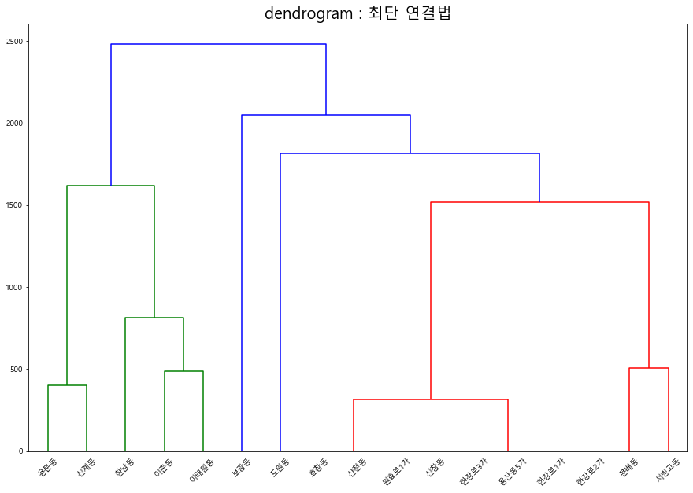

```python
plt.figure(figsize=(15,10))
dendrogram(single_dist,
           labels = EmdDF['EMD'].to_numpy(),
           leaf_rotation=45,
           leaf_font_size=10,
)
plt.title('dendrogram : 최단 연결법', fontdict={'fontsize':20})
plt.show()
```

**[ 계층적 군집 분석 ]** 최장 연결법

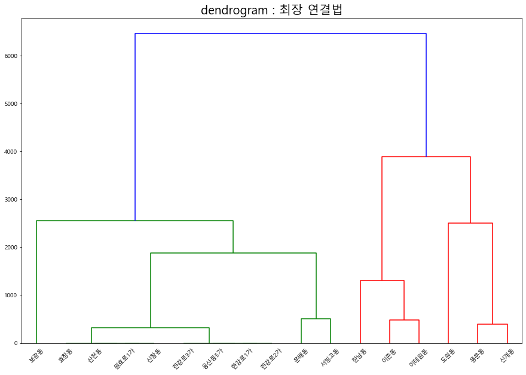

```python
complete_dist = linkage(x,method='complete')

# single_dist = linkage(Emd_stdDF[['SUPPLY', 'EXCESS_DEMAND']],method='single')

plt.figure(figsize = (15,10))
dendrogram(complete_dist,
           labels = EmdDF['EMD'].to_numpy(),
           leaf_rotation = 45,
           leaf_font_size = 10)
plt.title('dendrogram : 최장 연결법', fontdict={'fontsize':20})
plt.show()
```

**[군집 설정 및 시각화]** 군집 수 설정 후 그룹 별 산점도로 결과 확인 : 최단 연결법

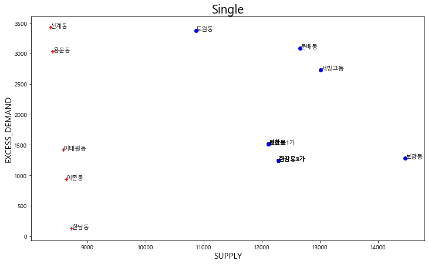

```python
singClustDF = EmdDF.copy()
singClustDF['Cluster'] = fcluster(single_dist,2,criterion='maxclust')
singClustDF['color'] = np.where(singClustDF['Cluster'] == 1, 'red', 'blue')
singClustDF['mark'] = np.where(singClustDF['Cluster'] == 1, '+', 'o')
plt.figure(1, figsize=(12, 7))
for RowIdx in range(len(singClustDF)):
    plt.scatter(singClustDF.SUPPLY[RowIdx], singClustDF.EXCESS_DEMAND[RowIdx], c=singClustDF.color[RowIdx],
                marker=singClustDF.mark[RowIdx])
    plt.text(singClustDF.SUPPLY[RowIdx] + 0.1, singClustDF.EXCESS_DEMAND[RowIdx],
             "{}".format(singClustDF.EMD[RowIdx]), fontsize=10)

plt.title('Single', fontsize=20)
plt.xlabel('SUPPLY', fontsize=14)
plt.ylabel('EXCESS_DEMAND', fontsize=14)
plt.show()
```

**[군집 설정 및 시각화]** 군집 수 설정 후 그룹 별 산점도로 결과 확인 : 최장 연결법

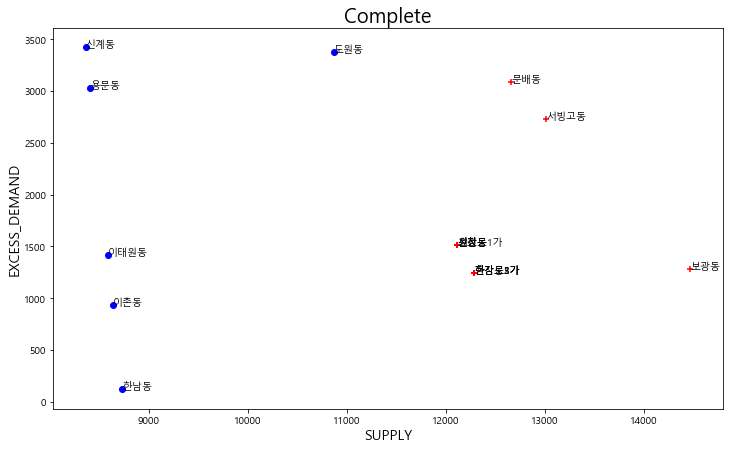

```python
compClustDF = EmdDF.copy()
compClustDF['Cluster'] = fcluster(complete_dist,2,criterion='maxclust')
compClustDF['color'] = np.where(compClustDF['Cluster'] == 1, 'red', 'blue')
compClustDF['mark'] = np.where(compClustDF['Cluster'] == 1, '+', 'o')
plt.figure(1, figsize=(12, 7))
for RowIdx in range(len(compClustDF)):
    plt.scatter(compClustDF.SUPPLY[RowIdx], compClustDF.EXCESS_DEMAND[RowIdx], c=compClustDF.color[RowIdx],
                marker=compClustDF.mark[RowIdx])
    plt.text(compClustDF.SUPPLY[RowIdx] + 0.1, compClustDF.EXCESS_DEMAND[RowIdx],
             "{}".format(compClustDF.EMD[RowIdx]), fontsize=10)

plt.title('Complete', fontsize=20)
plt.xlabel('SUPPLY', fontsize=14)
plt.ylabel('EXCESS_DEMAND', fontsize=14)
plt.show()
```

### 3. 비계층적 군집분석

#### 3.1 K-means clustering

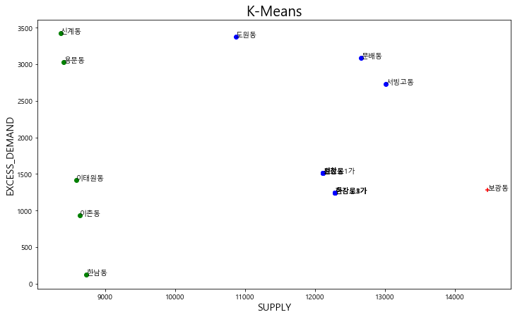

```python
# [군집 설정] 군집 수 = 3
KMeansDF = EmdDF.copy()
model = KMeans(n_clusters = 3, init = "random", n_init = 1, random_state = 10).fit(x)
KMeansDF['Cluster'] = model.labels_
KMeansDF['color'] = np.where(KMeansDF['Cluster'] == 1, 'red', np.where(KMeansDF['Cluster'] == 2, 'green', 'blue'))
KMeansDF['mark'] = np.where(KMeansDF['Cluster'] == 1, '+', 'o')
plt.figure(1, figsize=(12, 7))
for RowIdx in range(len(KMeansDF)):
    plt.scatter(KMeansDF.SUPPLY[RowIdx], KMeansDF.EXCESS_DEMAND[RowIdx], c=KMeansDF.color[RowIdx],
                marker=KMeansDF.mark[RowIdx])
    plt.text(KMeansDF.SUPPLY[RowIdx] + 0.1, KMeansDF.EXCESS_DEMAND[RowIdx],
             "{}".format(KMeansDF.EMD[RowIdx]), fontsize=10)

plt.title('K-Means', fontsize=20)
plt.xlabel('SUPPLY', fontsize=14)
plt.ylabel('EXCESS_DEMAND', fontsize=14)
plt.show()
```

#### 3.2 SOM(Self-Organization-Map)

```python
# 데이터 준비
somDF = DF.copy()
```

```python
# 읍면동 기준 중복 제거
somDF.drop_duplicates(['EMD'], keep='first', inplace=True)
```

```python
# 컬럼 선택
somDF = somDF[['POPULATION', 'HOUSEHOLD', 'PPH', 'SINGLE_HOUSEHOLD', 'SUPPLY', 'EXCESS_DEMAND']]
```

```python
# 데이터 확인
somDF.head()
```

|  | POPULATION | HOUSEHOLD | PPH | SINGLE_HOUSEHOLD | SUPPLY | EXCESS_DEMAND |
| --- | --- | --- | --- | --- | --- | --- |
| 0 | 9584 | 4577 | 2.093948 | 2207 | 7872 | 2454 |
| 3 | 9584 | 4577 | 2.093948 | 2207 | 7872 | 2454 |
| 4 | 9584 | 4577 | 2.093948 | 2207 | 7872 | 2454 |
| 8 | 7347 | 5251 | 1.399162 | 4146 | 8078 | 6019 |
| 14 | 7347 | 5251 | 1.399162 | 4146 | 8324 | 3802 |

- POPULATION: 인구수
- HOUSEHOLD: 가구수
- PPH: 세대당 인구수
- SINGLE_HOUSEHOLD: 1인 가구수
- SUPPLY: 주택수
- EXCESS_DEMAND: 초과수요

```python
# 데이터 표준화
scaler = StandardScaler().fit(somDF)
std_somDF = scaler.transform(somDF)
```

```python
!pip install minisom
```

```python
np.random.seed(10)
import minisom
som = minisom.MiniSom(13, 13, input_len = std_somDF.shape[1],
                      topology = 'hexagonal',
                      random_seed = 10,
                      learning_rate = 0.5)
```

```python
# 가중치 초기화
som.random_weights_init(std_somDF)
starting_weights = som.get_weights().copy() # 초기 가중치 복사
```

```python
# Self-Organizing Maps 학습
som.train(std_somDF, 10)
```

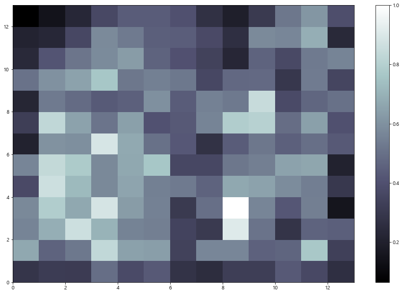

```python
# Plotting the response for each pattern in dataset
plt.rcParams['figure.figsize'] = 15, 10
plt.bone()
plt.pcolor(som.distance_map().T)  # plotting the distance map as background
plt.colorbar()
```